# OLS linear algebra

### **NOTES ON STATISTICS, PROBABILITY and MATHEMATICS**

### Interpretation of OLS:

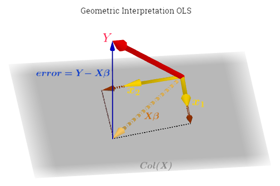

In the linear model $y = \beta_0 + \beta_1 x_1 + \beta_2 x_2 + ... \beta_n x_n +\varepsilon$ projection is key in the linear algebra of the model.

Why project? Because $\mathbf{X} \mathbf{\beta} = \mathbf{y}$ may have no solution if $\mathbf{y}$ it is not in the column space of $\mathbf{X}$. So instead we solve

$\mathbf{X\,\hat \beta}= \mathbf{\hat y}\small \tag 1$

where $\mathbf{\hat y}$ is the projection of the original outcome $\mathbf{y}$ on the column space of the regressors $\mathbf{X}$, or $\mathscr C (\mathbf{X})$.

The key is to see that $\Large \mathbf{y} - \mathbf{X\hat \beta}=\varepsilon$ is the error, and is perpendicular to $c(\mathbf{X})$.

Therefore, $\mathbf{X}^T (\mathbf{y} - \mathbf{X\hat \beta}) =0 \small \tag 2$

because we are dotting every vector in the $Col(\mathbf{X})$ with the error vector, and the errors are orthogonal. In other words, the error $\mathbf{e}$ is in the null space of $\mathbf{X}^T$.

Working on equation (2) we get to the NORMAL EQUATIONS (they are called the **normal equations** because they specify that the residual must be normal (orthogonal) to every vector in the span of $A$:

$\color{blue}{\mathbf{X}^T \mathbf{X\,\hat \beta} = \mathbf{X}^T \mathbf{y}} \quad \text{ NORMAL EQUATIONS}\tag { 3}$

INTERLUDE:

What does $X^\top X$ look like if we consider only one regressor (in blue): $x_{i1}$?

$\begin{align} X^\top X &= \begin{bmatrix} \color{blue}{1} & \color{blue}{1} & \color{blue}{1} &\color{blue}{\cdots}\\ \color{blue}{x_{11}} & \color{blue}{x_{21}} & \color{blue}{x_{31}} &\color{blue}{\cdots}\\ x_{12} & x_{22} & x_{32} &\cdots\\ \vdots & \vdots & \vdots &\ddots \end{bmatrix}\begin{bmatrix} \color{blue}{1} & \color{blue}{x_{11}} & x_{12} & \cdots\\ \color{blue}{1} & \color{blue}{x_{21}} & x_{22} & \cdots\\ \color{blue}{1} & \color{blue}{x_{31}} & x_{32} & \cdots\\ \color{blue}{\vdots} & \color{blue}{\vdots} & \vdots & \ddots \end{bmatrix} \\[2ex] \underset{\text{blue elements only}}{=}&\quad\color{blue}{\begin{bmatrix}n & \sum x_{i1}\\ \sum x_{i1} & \sum x_{i1}^2\end{bmatrix}} \end{align}$

Obtaining the determinant of this matrix:

$det(X^\top X) = n \sum x_{i1}^2 - \left[ \sum x_{i1} \right]^2 \underset{*}{=}n\, \sum (x_{i1}-\bar x)^2$

$(*)$ since the [shortcut formula for the variance](https://drive.google.com/file/d/0Bwl-HpVJ_5PeRWp2N3I5UVBrVVk/view?usp=sharing) is $\sigma^2 = \frac{\sum (x-\mu)^2}{n}=\frac{n\,\left(\sum x^2\right) - \left(\sum x\right)^2}{n^2}$

Leading to the formula for $(X^\top X)^{-1}$

$\begin{align} (X^\top X)^{-1} &= \frac{1}{n\, \sum (x_{i1}-\bar x)^2}\color{blue}{\begin{bmatrix}\sum x_{i1}^2 & -\sum x_{i1}\\ -\sum x_{i1} & n\end{bmatrix}}\\[2ex] &\underset{\text{simpler indices}}{=} \begin{bmatrix}\frac{\sum x_i^2}{n\sum(x_i - \bar x)^2} & \frac{-\sum x_i}{n\sum(x_i - \bar x)^2}\\\frac{-\sum x_i}{n\sum(x_i - \bar x)^2}& \frac{1}{\sum(x_i - \bar x)^2}\end{bmatrix} \end{align}$

Isolating $\mathbf{\hat \beta}$:

$\left(\mathbf{X^TX}\right)^{-1} \, \mathbf{X}^T \mathbf{y} = \mathbf{\hat \beta} \small \tag 4$

Plugging these results into equation (1):

$\color{red}{\mathbf{X}\,\left(\mathbf{X^TX}\right)^{-1} \, \mathbf{X}^T\,\,\, \mathbf{y} =\mathbf{X}\,\mathbf{\hat \beta}= \mathbf{\hat y}} \tag 5$

The projection matrix (which the same as the **hat matrix**) is defined as:

$\color{blue}{\mathbf{H}= \mathbf{X} \left(\mathbf{X}^{T} \mathbf{X} \right)^{-1} \mathbf{X} ^{T}} \text{ PROJECTION MATRIX} \tag 6$

because it put a “hat” on the $\mathbf{y}$. It is both symmetrical and idempotent, as it corresponds to a projection matrix.

Its orthogonal complement, also referred to as the *annihilator*, is:

$\mathbf{M}= \mathbf{I}_n- \mathbf{H} \small \tag 7$

$n$ representing the number of rows and columns of $\mathbf{H}$.

#### Properties:

$\mathbf{H}\,\,\mathbf{X} = \mathbf{X}$

$\mathbf{M}\,\,\mathbf{X} = \left(\mathbf{I}_n- \mathbf{H}\right)\,\mathbf{X}= \mathbf{X}- \left(\mathbf{H}\,\mathbf{X}\right)$

The residuals can be represented as:

$\mathbf{e}=\mathbf{M}\mathbf{y} =\mathbf{y}- \mathbf{H}\mathbf{y}= \mathbf{y}-\mathbf{\hat y}$

The loss function (objective function) that is minimized is the sum of the squared residuals:

$f(\beta) = \bf (y - X\beta)^\prime(y - X\beta) \text{ OBJECTIVE FUNCTION}$

### Random vectors:

[One way to tell a random vector from a non-random one is to contemplate what changes would occur if the data-collection process was replicated. Any vector that could change must do so due to the random changes modeled by $\epsilon$, because all other values–the $\mathbf{X}$ and $\mathbf{\beta}$–are modeled as constants](http://stats.stackexchange.com/q/178743/67822).

$\mathbf{X}$ are considered *fixed measurements* without error, whereas the following are *random vectors*:

$\mathbf{\hat y}$ (fitted values), $\hat \beta$ (betas) and $\mathbf{e}$ (residuals).

[Home Page](http://rinterested.github.io/statistics/index.html)

**NOTE: These are tentative notes on different topics for personal use - expect mistakes and misunderstandings.**